# Análise do Board Games Dataset (BGDB)

Cesae Digital | Cátia Silva

O presente notebook descreve uma pipeline de análise de dados aplicada ao dataset *Board Game Database from BoardGameGeek (BGDB)*, obtido via Kaggle. Inicialmente, é realizada a preparação do dataset (importação, renomeação de variáveis e tratamento de inconsistências), seguida de análises exploratórias em contexto *Business Intelligence* (univariada, bivariada e multivariada). Posteriormente, na vertente *Business Analytics* são construídos modelos para previsão do rating médio e classificação de jogos de topo. Por fim, é desenvolvido um sistema de recomendação baseado em conteúdo, orientado para o apoio à decisão.

# 1 Importação e preparação do dataset

Antes de qualquer análise, é fundamental compreender a estrutura do dataset e garantir a consistência das variáveis.

Numa fase inicial, é analisado o ficheiro *games.csv*, bem como o significado das principais variáveis nele contidas. O dataset reúne informação sobre jogos de tabuleiro registados na plataforma BoardGameGeek (BGG), incluindo características do jogo, como a complexidade, a duração média e o número de jogadores, assim como indicadores associados à avaliação e à popularidade na comunidade de utilizadores.

O dataset foi obtido no Kaggle:

https://www.kaggle.com/datasets/threnjen/board-games-database-from-boardgamegeek?resource=download

```r
boardgames <- read.csv("games.csv", header = TRUE, stringsAsFactors = FALSE)
glimpse(boardgames)
```

```
## Rows: 21,925
## Columns: 48
## $ BGGId               <int> 1, 2, 3, 4, 5, 6, 7, 8, 9, 10, 11, 12, 13, 14, 15,…
## $ Name                <chr> "Die Macher", "Dragonmaster", "Samurai", "Tal der …
## $ Description         <chr> "die macher game seven sequential political race d…
## $ YearPublished       <int> 1986, 1981, 1998, 1992, 1964, 1989, 1978, 1993, 19…
## $ GameWeight          <dbl> 4.3206, 1.9630, 2.4859, 2.6667, 2.5031, 3.0000, 1.…
## $ AvgRating           <dbl> 7.61428, 6.64537, 7.45601, 6.60006, 7.33861, 6.553…
## $ BayesAvgRating      <dbl> 7.10363, 5.78447, 7.23994, 5.67954, 7.14189, 5.546…
## $ StdDev              <dbl> 1.57979, 1.45440, 1.18227, 1.23129, 1.33583, 1.653…
## $ MinPlayers          <int> 3, 3, 2, 2, 2, 2, 2, 2, 2, 2, 2, 2, 3, 3, 2, 3, 2,…
## $ MaxPlayers          <int> 5, 4, 4, 4, 6, 6, 2, 5, 4, 6, 7, 5, 4, 4, 6, 4, 2,…
## $ ComAgeRec           <dbl> 14.366667, NA, 9.307692, 13.000000, 11.410256, 13.…
## $ LanguageEase        <dbl> 1.395833, 27.000000, 1.000000, 256.000000, 21.1529…
## $ BestPlayers         <int> 5, 0, 3, 0, 4, 0, 0, 0, 3, 4, 5, 3, 4, 4, 4, 0, 0,…
```

[output cut: 35 more lines]

```r
print("Dimensão do dataset:")
```

```
## [1] "Dimensão do dataset:"
```

```r
dim(boardgames)
```

```
## [1] 21925    48
```

```r
print("Nome das colunas: ")
```

```
## [1] "Nome das colunas: "
```

```r
names(boardgames)
```

```
##  [1] "BGGId"               "Name"                "Description"
##  [4] "YearPublished"       "GameWeight"          "AvgRating"
##  [7] "BayesAvgRating"      "StdDev"              "MinPlayers"
## [10] "MaxPlayers"          "ComAgeRec"           "LanguageEase"
## [13] "BestPlayers"         "GoodPlayers"         "NumOwned"
## [16] "NumWant"             "NumWish"             "NumWeightVotes"
## [19] "MfgPlaytime"         "ComMinPlaytime"      "ComMaxPlaytime"
## [22] "MfgAgeRec"           "NumUserRatings"      "NumComments"
## [25] "NumAlternates"       "NumExpansions"       "NumImplementations"
## [28] "IsReimplementation"  "Family"              "Kickstarted"
## [31] "ImagePath"           "Rank.boardgame"      "Rank.strategygames"
## [34] "Rank.abstracts"      "Rank.familygames"    "Rank.thematic"
## [37] "Rank.cgs"            "Rank.wargames"       "Rank.partygames"
## [40] "Rank.childrensgames" "Cat.Thematic"        "Cat.Strategy"
## [43] "Cat.War"             "Cat.Family"          "Cat.CGS"
## [46] "Cat.Abstract"        "Cat.Party"           "Cat.Childrens"
```

Após a importação do dataset, é analisada a sua dimensão, nomeadamente o número de linhas e colunas, bem como confirmada a lista de variáveis disponíveis. De forma geral, o conjunto de dados inclui informação relativa à identificação dos jogos, às suas características principais e ao envolvimento da comunidade de utilizadores, destacando-se as seguintes variáveis:

- *BGGId*, que identifica unicamente cada jogo na plataforma BoardGameGeek.
- *Name* e *Description*, que fornecem o nome e uma descrição do jogo.
- *YearPublished*, que indica o ano de publicação.
- *GameWeight* (*complexity*), que representa a complexidade ou dificuldade média atribuída pela comunidade.
- *AvgRating* (*average_rating*), correspondente ao rating médio do jogo, sendo esta a variável central do estudo.
- *BayesAvgRating*, que consiste numa versão ajustada do rating, reduzindo o impacto de jogos com poucos votos.
- *MinPlayers* e *MaxPlayers*, que caracterizam o intervalo de jogadores recomendado.
- *MfgPlayTime*, *ComMinPlaytime* e *ComMaxPlaytime*, que descrevem a duração do jogo, segundo o fabricante e a comunidade.
- *NumOwned*, *NumWant*, *NumWish* e *NumUserRatings*, que refletem diferentes dimensões do envolvimento e da popularidade do jogo junto da comunidade.
- Variáveis de ranking (*Rank:…*) e de categorização (*Cat:…*), que permitem enquadrar cada jogo em diferentes tipos e géneros, como estratégia, família ou party games.

## 1.1 Renomeação de colunas

De modo a facilitar a leitura do código e a interpretação dos resultados, procedeu-se à renomeação das colunas, em que foram adotados nomes mais curtos, consistentes e semanticamente claros.

```r
rename_map <- c(
  "BGGId"                = "id",
  "Name"                 = "name",
  "Description"          = "description",
  "YearPublished"        = "year_published",
  "GameWeight"           = "complexity",
  "AvgRating"            = "average_rating",
  "BayesAvgRating"       = "bayes_average_rating",
  "StdDev"               = "rating_sd",
  "MinPlayers"           = "min_players",
  "MaxPlayers"           = "max_players",
  "ComAgeRec"            = "age_recommended",
  "LanguageEase"         = "language_dependence",
  "BestPlayers"          = "best_players",
  "GoodPlayers"          = "good_players",
  "NumOwned"             = "num_owned",
  "NumWant"              = "num_want",
  "NumWish"              = "num_wish",
  "NumWeightVotes"       = "num_weight_votes",
  "MfgPlaytime"          = "playtime",
  "ComMinPlaytime"       = "min_playtime",
  "ComMaxPlaytime"       = "max_playtime",
  "MfgAgeRec"            = "mfg_age_rec",
  "NumUserRatings"       = "users_rated",
  "NumComments"          = "num_comments",
  "NumAlternates"        = "num_alternates",
  "NumExpansions"        = "num_expansions",
  "NumImplementations"   = "num_implementations",
  "IsReimplementation"   = "is_reimplementation",
  "Family"               = "family",
  "Kickstarted"          = "kickstarted",
  "ImagePath"            = "image_path",

  # Rankings
  "Rank.boardgame"       = "Rank.boardgame",
  "Rank.strategygames"   = "Rank.strategygames",
  "Rank.abstracts"       = "Rank.abstracts",
  "Rank.familygames"     = "Rank.familygames",
  "Rank.thematic"        = "Rank.thematic",
  "Rank.cgs"             = "Rank.cgs",
  "Rank.wargames"        = "Rank.wargames",
  "Rank.partygames"      = "Rank.partygames",
  "Rank.childrensgames"  = "Rank.childrensgames",

  # Categorias
  "Cat.Thematic"         = "Cat.Thematic",
  "Cat.Strategy"         = "Cat.Strategy",
  "Cat.War"              = "Cat.War",
  "Cat.Family"           = "Cat.Family",
  "Cat.CGS"              = "Cat.CGS",
  "Cat.Abstract"         = "Cat.Abstract",
  "Cat.Party"            = "Cat.Party",
  "Cat.Childrens"        = "Cat.Childrens"
)

names(boardgames) <- rename_map[names(boardgames)]
```

## 1.2 Conversão de tipos de dados

Após a renomeação, ajustaram-se os tipos de dados, assegurando que cada variável é representada de forma coerente com a sua natureza (numérica, categórica ou lógica).

```r
tipos <- list(
  character = c("name", "description", "family", "image_path", "best_players", "good_players"),
  numeric = c("complexity", "average_rating", "bayes_average_rating", "rating_sd", "language_dependence"),
  integer = c(
    "id", "year_published", "min_players", "max_players",
    "age_recommended", "num_owned", "num_want", "num_wish",
    "num_weight_votes", "playtime", "min_playtime", "max_playtime",
    "mfg_age_rec", "users_rated", "num_comments",
    "num_alternates", "num_expansions", "num_implementations",
    "Rank.boardgame", "Rank.strategygames", "Rank.abstracts",
    "Rank.familygames", "Rank.thematic", "Rank.cgs",
    "Rank.wargames", "Rank.partygames", "Rank.childrensgames"
  ),
  logical = c("kickstarted", "is_reimplementation"),
  factor = c(
    "Cat.Thematic", "Cat.Strategy", "Cat.War", "Cat.Family",
    "Cat.CGS", "Cat.Abstract", "Cat.Party", "Cat.Childrens"
  )
)


for (tipo in names(tipos)) {
  for (col in tipos[[tipo]]) {

    if (!col %in% names(boardgames)) next

    if (tipo == "character") {
      boardgames[[col]] <- as.character(boardgames[[col]])

    } else if (tipo == "numeric") {
      boardgames[[col]] <- as.numeric(boardgames[[col]])

    } else if (tipo == "integer") {
      boardgames[[col]] <- as.integer(boardgames[[col]])

    } else if (tipo == "logical") {
      boardgames[[col]] <- boardgames[[col]] == 1

    } else if (tipo == "factor") {
      boardgames[[col]] <- as.factor(boardgames[[col]])
    }
  }
}

for (col in names(boardgames)) {
  cat(col, ":", class(boardgames[[col]]), "\n")
}
```

```
## id : integer
## name : character
## description : character
## year_published : integer
## complexity : numeric
## average_rating : numeric
## bayes_average_rating : numeric
## rating_sd : numeric
## min_players : integer
## max_players : integer
## age_recommended : integer
## language_dependence : numeric
## best_players : character
## good_players : character
## num_owned : integer
## num_want : integer
## num_wish : integer
## num_weight_votes : integer
## playtime : integer
## min_playtime : integer
## max_playtime : integer
## mfg_age_rec : integer
## users_rated : integer
## num_comments : integer
## num_alternates : integer
## num_expansions : integer
## num_implementations : integer
## is_reimplementation : logical
## family : character
## kickstarted : logical
## image_path : character
## Rank.boardgame : integer
## Rank.strategygames : integer
## Rank.abstracts : integer
## Rank.familygames : integer
## Rank.thematic : integer
## Rank.cgs : integer
## Rank.wargames : integer
## Rank.partygames : integer
## Rank.childrensgames : integer
## Cat.Thematic : factor
## Cat.Strategy : factor
## Cat.War : factor
## Cat.Family : factor
## Cat.CGS : factor
## Cat.Abstract : factor
## Cat.Party : factor
## Cat.Childrens : factor
```

## 1.3 Análise de valores em falta

A análise dos valores em falta permite definir a estratégia mais adequada para as etapas seguintes do trabalho, bem como avaliar o impacto destes valores na interpretação dos resultados.

```r
sort(colSums(is.na(boardgames)), decreasing = TRUE)[1:20]
```

```
##  language_dependence      age_recommended                   id
##                 5891                 5530                    0
##                 name          description       year_published
##                    0                    0                    0
##           complexity       average_rating bayes_average_rating
##                    0                    0                    0
##            rating_sd          min_players          max_players
##                    0                    0                    0
##         best_players         good_players            num_owned
##                    0                    0                    0
##             num_want             num_wish     num_weight_votes
##                    0                    0                    0
##             playtime         min_playtime
##                    0                    0
```

No conjunto de dados em estudo, as variáveis *language_dependence* e *age_recommended* apresentam um número elevado de valores em falta, uma vez que nem todos os jogos têm esta informação registada na BoardGameGeek.

Na fase de *Business Intelligence*, os valores em falta foram mantidos e as análises foram realizadas apenas sobre os valores observados, de forma a preservar a distribuição real dos dados e evitar a introdução de enviesamentos artificiais.

```r
summary(boardgames$language_dependence)
```

```
##    Min. 1st Qu.  Median    Mean 3rd Qu.    Max.    NA's
##    1.00   24.03  138.00  216.46  351.00 1757.00    5891
```

```r
summary(boardgames$age_recommended)
```

```
##    Min. 1st Qu.  Median    Mean 3rd Qu.    Max.    NA's
##   2.000   8.000  10.000   9.818  12.000  21.000    5530
```

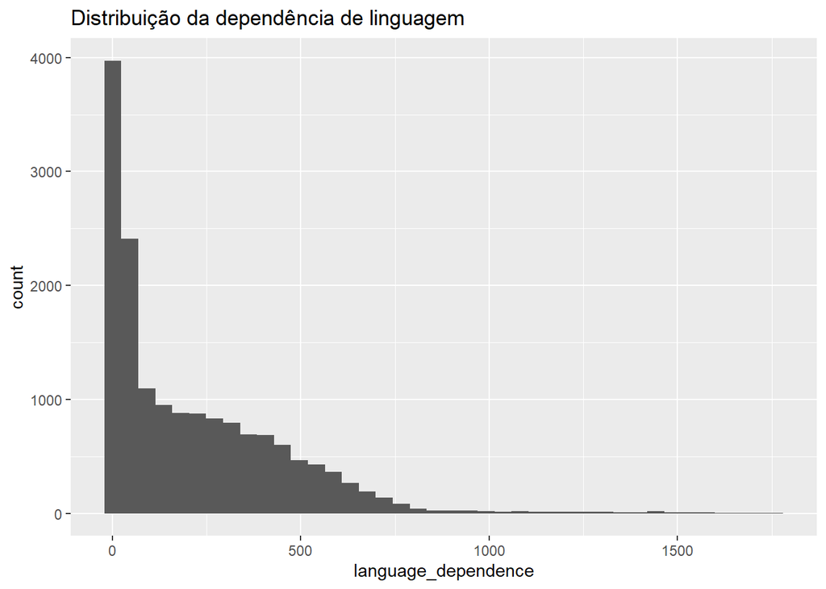

```r
ggplot(boardgames, aes(language_dependence)) +
  geom_histogram(bins = 40, na.rm = TRUE) +
  labs(title = "Distribuição da dependência de linguagem")
```

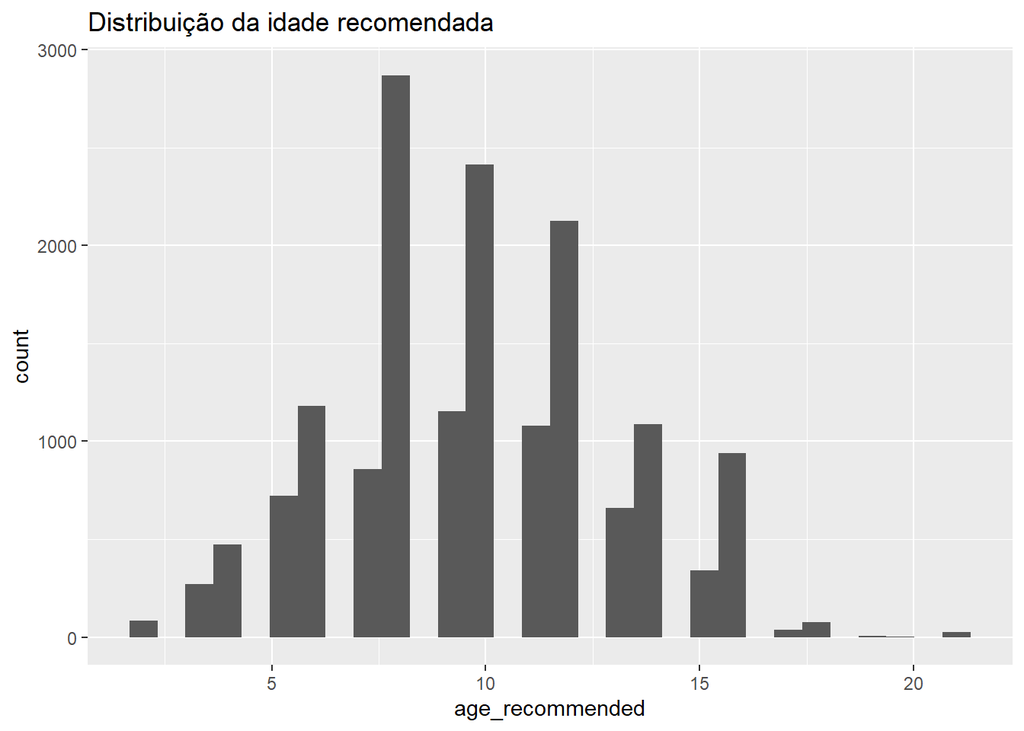

```r
ggplot(boardgames, aes(age_recommended)) +
  geom_histogram(bins = 30, na.rm = TRUE) +
  labs(title = "Distribuição da idade recomendada")
```

# 2 Preparação e criação de variáveis derivadas

Nesta etapa foi realizada uma verificação de consistência temporal e a criação de variáveis derivadas para apoiar a análise exploratória (**BI**) e as fases posteriores de *Business Analytics* (**BA**).

Deste modo, foi aplicado um filtro temporal, restringindo *year_published* ao intervalo compreendido entre 1900 e o ano atual, de forma a excluir eventuais entradas inconsistentes que poderiam comprometer a análise.

```r
summary(boardgames$year_published)
```

```
##    Min. 1st Qu.  Median    Mean 3rd Qu.    Max.
##   -3500    2001    2011    1985    2017    2021
```

```r
boardgames <- boardgames[boardgames$year_published >= 1900 & boardgames$year_published <= 2025, ]
```

Adicionalmente, foram definidas várias variáveis derivadas, com vista a enriquecer a caracterização dos jogos:

- *avg_playtime*, que representa uma estimativa da duração média de um jogo, calculada a partir dos tempos mínimo e máximo reportados;
- *player_range*, correspondente à diferença entre o número máximo e mínimo de jogadores, permitindo avaliar a flexibilidade do jogo relativamente ao tamanho do grupo;
- *is_modern*, um indicador binário que distingue jogos modernos (publicados a partir de 2000) de jogos mais antigos;
- *is_top_game*, uma variável binária construída com base no *average_rating*, utilizada posteriormente em tarefas de classificação e que identifica como “jogos de topo” aqueles cuja classificação média é igual ou superior a 8.

Estas transformações mantêm intactos os valores originais do dataset e têm como principal finalidade facilitar a interpretação dos resultados e apoiar as análises desenvolvidas nas etapas seguintes.

```r
boardgames$avg_playtime <- (boardgames$min_playtime + boardgames$max_playtime) / 2

boardgames$player_range <- boardgames$max_players - boardgames$min_players

boardgames$is_modern <- ifelse(boardgames$year_published >= 2000, 1, 0)

boardgames$is_top_game <- ifelse(boardgames$average_rating >= 8, 1, 0)

dim(boardgames)
```

```
## [1] 21616    52
```

```r
head(boardgames[, c("year_published", "avg_playtime", "player_range", "is_modern", "is_top_game")])
```

```
##   year_published avg_playtime player_range is_modern is_top_game
## 1           1986          240            2         0           0
## 2           1981           30            1         0           0
## 3           1998           45            2         0           0
## 4           1992           60            2         0           0
## 5           1964           90            4         0           0
## 6           1989          240            4         0           0
```

# 3 Análise Univariada

A análise univariada tem como objetivo compreender a distribuição individual de cada variável, identificar padrões gerais, assimetrias e possíveis valores extremos, sem considerar ainda relações entre variáveis.

## 3.1 Rating Médio

A variável *average_rating* corresponde à avaliação média atribuída pela comunidade a cada jogo e assume um papel central neste trabalho, uma vez que funciona como indicador global da qualidade percebida. Além disso, esta variável é utilizada nas fases posteriores de análise preditiva.

```r
summary(boardgames$average_rating)
```

```
##    Min. 1st Qu.  Median    Mean 3rd Qu.    Max.
##   1.041   5.846   6.460   6.432   7.057   9.595
```

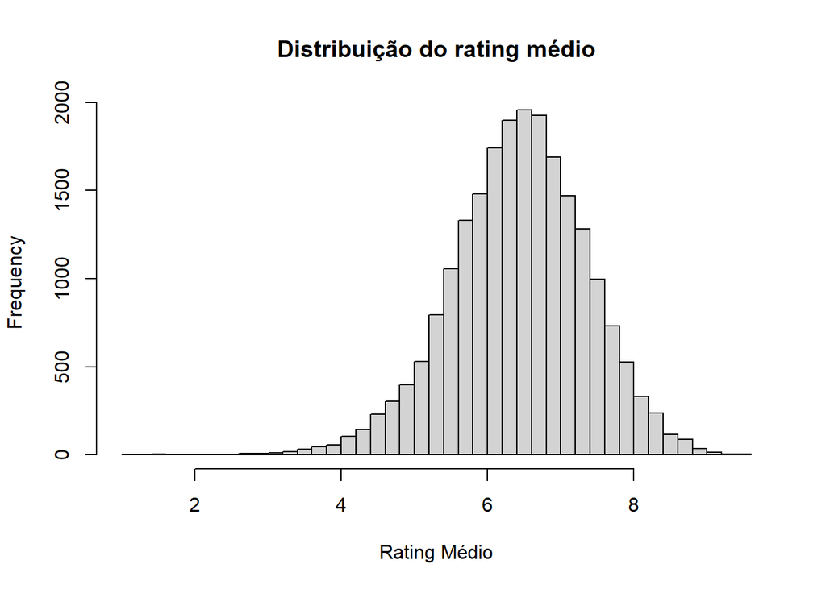

```r
hist(boardgames$average_rating, breaks=40,
     main="Distribuição do rating médio",
     xlab="Rating Médio")
```

A observação do histograma revela que a maioria dos jogos apresenta classificações situadas entre 6 e 8, intervalo que corresponde a avaliações consideradas “boas” pela comunidade de jogadores de tabuleiro. Enquanto que, osjogos com classificações muito baixas ou excecionalmente elevadas surgem com menor frequência.

Este padrão sugere que o *average_rating* é uma variável relativamente estável e adequada para análises comparativas, refletindo de forma consistente a perceção geral da qualidade dos jogos.

```r
top10_rating <- boardgames[
  order(boardgames$average_rating, decreasing = TRUE),
  c(
    "name",
    "average_rating",
    "bayes_average_rating",
    "users_rated",
    "num_owned",
    "complexity",
    "avg_playtime",
    "Rank.boardgame",
    "year_published"
  )
][1:10, ]

top10_rating
```

```
##                                                                name
## 20006                                                         Erune
## 21916         System Gateway (fan expansion for Android: Netrunner)
## 17508                                                   TerroriXico
## 19120                              The Fantasy Trip: Legacy Edition
## 14463                                                  Meeple Quest
## 10262                                       Wings of the Motherland
## 20216                                                        Aeolis
## 13020                                                   Gladiatoris
## 20666                                                   Flip & Fish
## 12852 Primer: The Gamer's Source for Battles from the Age of Reason
##       average_rating bayes_average_rating users_rated num_owned complexity
## 20006        9.59524              5.51947          42        17     0.0000
## 21916        9.48333              5.57641          36        90     0.0000
## 17508        9.42857              5.50463          70        36     2.5000
```

[output cut: 18 more lines]

O top 10 de jogos com maior *average_rating* é dominado por títulos com poucas avaliações, o que explica os valores extremamente elevados observados. Esta situação é confirmada pelo bayes_average_rating, que apresenta valores significativamente mais baixos, refletindo o ajustamento feito ao reduzido número de votos.

Em termos de popularidade e ranking global, estes jogos ocupam posições modestas, indicando que se tratam maioritariamente de jogos de nicho. As características de complexidade e duração são bastante variadas, o que sugere que ratings muito elevados não estão associados a um único perfil de jogo, mas sim a públicos específicos altamente satisfeitos.

## 3.2 Complexidade do jogo

A variável *complexity* (GameWeight) mede o grau de complexidade do jogo, refletindo o esforço necessário para aprender regras e tomar decisões.

```r
summary(boardgames$complexity)
```

```
##    Min. 1st Qu.  Median    Mean 3rd Qu.    Max.
##   0.000   1.333   2.000   1.986   2.533   5.000
```

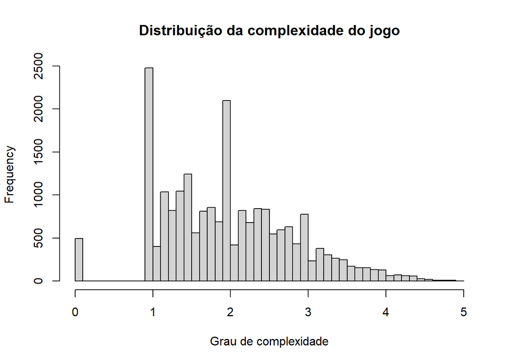

```r
hist(boardgames$complexity, breaks=40,
     main="Distribuição da complexidade do jogo",
     xlab="Grau de complexidade")
```

No conjunto de dados, observa-se uma clara concentração de jogos com níveis de complexidade baixos a médios (entre 1 e 3), o que aponta para uma preferência geral por jogos acessíveis, mas com alguma profundidade.

```r
top10_complexity <- boardgames[
  order(boardgames$complexity, decreasing = TRUE),
  c("name", "complexity", "average_rating", "year_published")
][1:10, ]

top10_complexity
```

```
##                                                        name complexity
## 4524                                 Empire (Third Edition)     5.0000
## 19703              Warhammer Fantasy Battle (Third Edition)     5.0000
## 2012                                       Patton in Flames     4.9167
## 13496                       Atlantic Wall: D-Day to Falaise     4.8889
## 16947                                     D-Day at Iwo Jima     4.8889
## 7487  Star Fleet Battles Silver Anniversary Master Rulebook     4.8571
## 2687                                     Europa Universalis     4.8537
## 4125                                         A World at War     4.8447
## 16946        Lucky Forward: Patton's Third Army in Lorraine     4.8333
## 4677                Advanced European Theater of Operations     4.8235
##       average_rating year_published
## 4524         5.82558           1981
## 19703        7.18128           1987
## 2012         6.96308           2000
## 13496        8.22013           2014
## 16947        6.86732           2018
## 7487         8.59636           2004
## 2687         6.84085           1993
## 4125         7.59749           2003
## 16946        8.34848           2020
## 4677         7.63617           2001
```

Os jogos mais complexos (valores próximos de 5) correspondem sobretudo a títulos de cariz histórico e estratégico, frequentemente associados a wargames. Apesar da elevada complexidade, as classificações médias destes jogos são bastante heterogéneas, o que indica que um maior grau de complexidade não garante, por si só, uma melhor avaliação

## 3.3 Tempo médio por jogo

A variável *avg_playtime* estima a duração média de uma partida, calculada a partir dos tempos mínimo e máximo reportados.

```r
summary(boardgames$avg_playtime)
```

```
##     Min.  1st Qu.   Median     Mean  3rd Qu.     Max.
##     0.00    22.50    42.50    77.75    75.00 60000.00
```

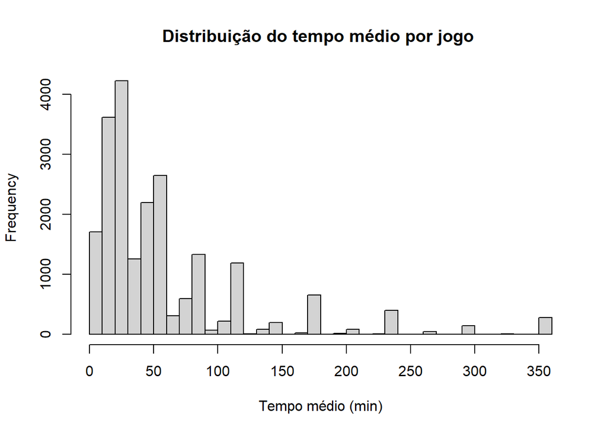

```r
xlim <- quantile(boardgames$avg_playtime, 0.98, na.rm = TRUE)
hist(boardgames$avg_playtime[boardgames$avg_playtime <= xlim], breaks=40,
     main="Distribuição do tempo médio por jogo ",
     xlab="Tempo médio (min)")
```

A distribuição desta variável mostra que a maioria dos jogos apresenta durações curtas a moderadas, o que sugere uma preferência por experiências de jogo compatíveis com sessões mais acessíveis e flexíveis.

Os jogos com tempos médios muito elevados surgem como casos pontuais e correspondem, em geral, a títulos mais complexos e direcionados a jogadores dedicados. Assim, a duração do jogo surge como um fator de caracterização do público-alvo, mais do que como um indicador direto de qualidade.

```r
top10_playtime <- boardgames[!is.na(boardgames$avg_playtime), ]

top10_playtime <- top10_playtime[
  order(top10_playtime$avg_playtime, decreasing = TRUE),
  c("name", "avg_playtime", "complexity", "year_published")
][1:10, ]

top10_playtime
```

```
##                                                        name avg_playtime
## 3026  The Campaign for North Africa: The Desert War 1940-43        60000
## 9260                             1914: Offensive à outrance        17280
## 3910                                      Drang Nach Osten!        12000
## 7809                                              Case Blue        11970
## 18187                                        The Enigma Box         8000
## 13496                       Atlantic Wall: D-Day to Falaise         7260
## 218                                         Empires in Arms         6060
## 3395                                        The Longest Day         5400
## 5716                               Guderian's Blitzkrieg II         4500
## 18052                               1985: Under an Iron Sky         4380
##       complexity year_published
## 3026      4.7094           1979
## 9260      4.0625           2013
## 3910      4.1000           1973
## 7809      4.5735           2007
## 18187     3.8571           2017
## 13496     4.8889           2014
## 218       4.4067           1983
## 3395      4.1370           1979
## 5716      4.3889           2001
## 18052     4.2857           2018
```

A tabela evidencia que os jogos com maior tempo médio de jogo correspondem quase exclusivamente a títulos muito complexos, maioritariamente wargames clássicos. Estes jogos apresentam durações extremamente elevadas, refletindo experiências prolongadas e altamente especializadas, direcionadas a um público muito específico.

## 3.4 Idade recomendada

A variável *age_recommended* indica a idade mínima sugerida pela comunidade para a prática de cada jogo, permitindo caracterizar o público-alvo e o grau de acessibilidade.

```r
summary(boardgames$age_recommended)
```

```
##    Min. 1st Qu.  Median    Mean 3rd Qu.    Max.    NA's
##   2.000   8.000  10.000   9.849  12.000  21.000    5444
```

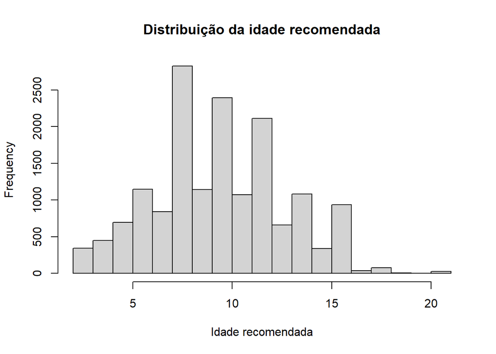

```r
hist(boardgames$age_recommended, breaks=25,
     main="Distribuição da idade recomendada",
     xlab="Idade recomendada")
```

A distribuição observada mostra uma predominância de jogos destinados a públicos jovens e familiares, maioritariamente acessíveis a partir da pré-adolescência. Embora existam jogos pensados especificamente para adultos, mas não dominam o conjunto de dados.

## 3.5 Dependência de linguagem

A variável language_dependence reflete o grau de dependência do jogo relativamente à leitura e compreensão de texto durante a jogabilidade. No dataset, este indicador resulta de avaliações agregadas da comunidade da BoardGameGeek.

```r
summary(boardgames$language_dependence)
```

```
##    Min. 1st Qu.  Median    Mean 3rd Qu.    Max.    NA's
##     1.0    25.0   139.8   217.0   352.0  1757.0    5802
```

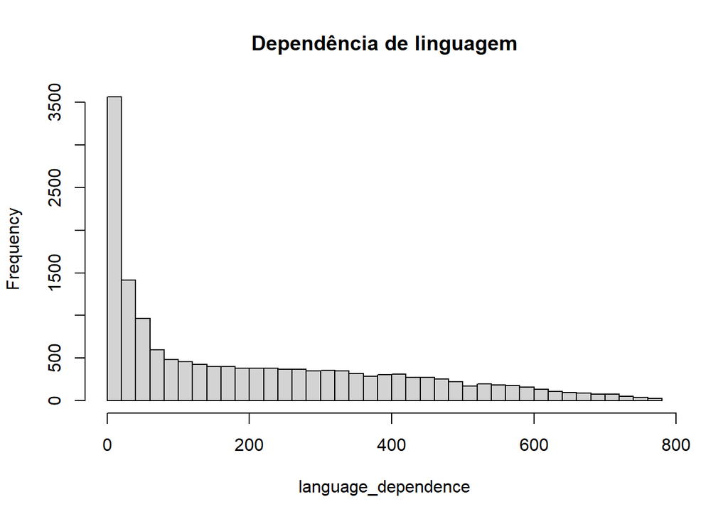

```r
xlim <- quantile(boardgames$language_dependence, 0.98, na.rm = TRUE)
hist(boardgames$language_dependence[boardgames$language_dependence <= xlim], breaks=40,
     main="Dependência de linguagem",
     xlab="language_dependence")
```

Através da análise do histograma, verifica-se que grande parte dos jogos requer pouca leitura ou compreensão linguística, o que facilita a sua acessibilidade a diferentes públicos e idiomas. Ainda assim, observa-se a existência de um subconjunto mais restrito de jogos fortemente dependentes de texto, geralmente associado a experiências narrativas ou a maior complexidade temática.

## 3.6 Evolução temporal

Após analisar as características individuais dos jogos, torna-se relevante observar a evolução do mercado ao longo do tempo e tendências no número de lançamentos anuais.

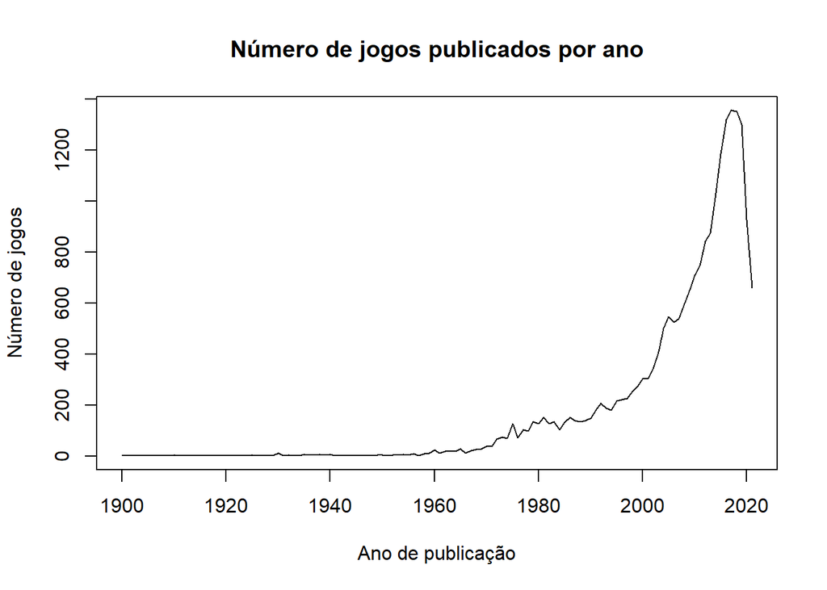

```r
anos <- table(boardgames$year_published)

anos_df <- data.frame(
  year = as.numeric(names(anos)),
  n_jogos = as.numeric(anos)
)

anos_df <- anos_df[order(anos_df$year), ]

plot(anos_df$year, anos_df$n_jogos, type = "l",
     main = "Número de jogos publicados por ano",
     xlab = "Ano de publicação",
     ylab = "Número de jogos")
```

O gráfico evidencia uma expansão progressiva do número de jogos de tabuleiro publicados ao longo do tempo. Durante grande parte do século XX, o número de lançamentos anuais foi reduzido e relativamente estável, refletindo um mercado mais limitado e com menor diversidade de oferta.

A partir do final do século XX, e de forma mais marcada após o ano 2000, observa-se um aumento consistente no número de jogos publicados por ano. Este crescimento poderá estar relacionado com a consolidação dos jogos de tabuleiro modernos e com o maior envolvimento da comunidade de jogadores, bem como com a melhoria dos mecanismos de divulgação e registo de informação em plataformas especializadas como a BoardGameGeek.

# 4 Análise Bivariada

A análise bivariada permite explorar relações entre pares de variáveis, com o objetivo de identificar se determinadas características dos jogos estão associadas a classificações médias mais elevadas.

## 4.1 Complexidade vs Rating

O objetivo desta análise é verificar se o grau de complexidade de um jogo está associado à sua classificação média. Em particular, procura-se responder à questão (**BI**): jogos mais complexos tendem a ser melhor avaliados pela comunidade?

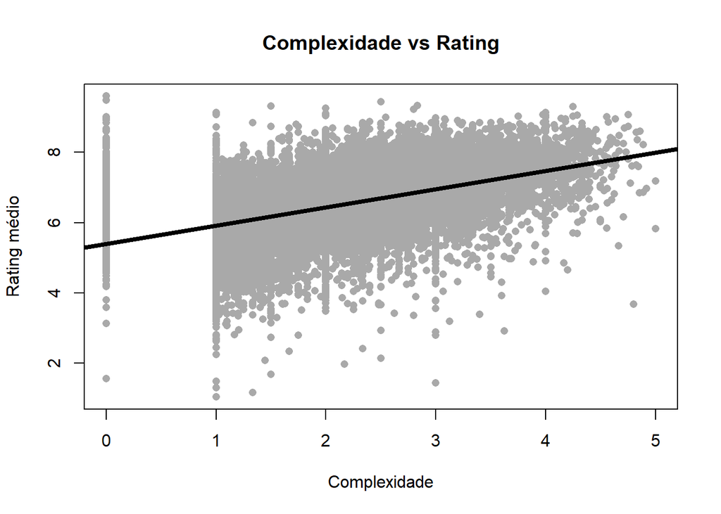

```r
plot(boardgames$complexity, boardgames$average_rating,
     pch = 16,
     col = "darkgray",
     xlab = "Complexidade",
     ylab = "Rating médio",
     main = "Complexidade vs Rating")

abline(lm(average_rating ~ complexity, data = boardgames),
       col = "black", lwd = 4)
```

```r
cor.test(boardgames$complexity,
         boardgames$average_rating,
         method = "spearman",
         use = "complete.obs")
```

```
##
##  Spearman's rank correlation rho
##
## data:  boardgames$complexity and boardgames$average_rating
## S = 8.3661e+11, p-value < 2.2e-16
## alternative hypothesis: true rho is not equal to 0
## sample estimates:
##       rho
## 0.5030068
```

A análise gráfica revela uma tendência positiva, na medida em que jogos mais complexos apresentam, em média, classificações ligeiramente superiores. Ainda assim, observa-se uma dispersão considerável dos valores ao longo de todos os níveis de complexidade.

A tendência observada é reforçada pela correlação de Spearman, que indica uma correlação positiva moderada e estatisticamente significativa (p-value < 0.001). Contudo, a complexidade não constitui, por si só, uma garantia de avaliações elevadas. Jogos mais exigentes parecem atrair um público mais especializado, enquanto jogos simples exibem avaliações bastante heterogéneas.

Após analisar a relação entre complexidade e classificação média, torna-se pertinente explorar se outras características do jogo, como a duração ou o número de jogadores, apresentam padrões semelhantes em relação ao rating.

## 4.2 Popularidade vs Rating

A relação entre a popularidade de um jogo, medida pelo número de utilizadores que o possuem (*num_owned*), , e o rating médio permite avaliar se jogos mais populares tendem a ser melhor avaliados.

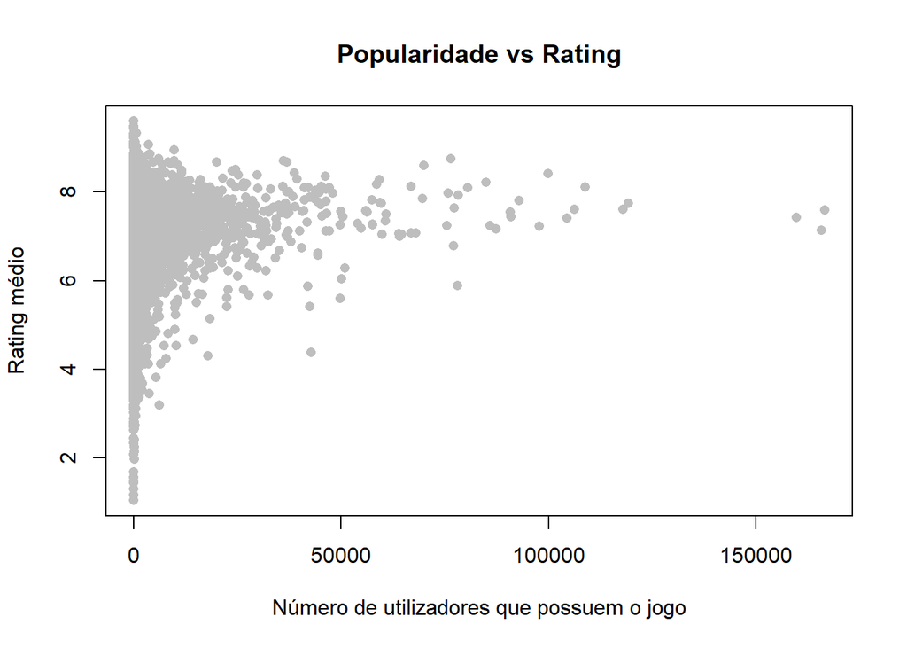

```r
plot(boardgames$num_owned, boardgames$average_rating,
     pch = 16, col = "gray",
     xlab = "Número de utilizadores que possuem o jogo",
     ylab = "Rating médio",
     main = "Popularidade vs Rating")
```

```r
cor.test(boardgames$num_owned,
         boardgames$average_rating,
         method = "spearman",
         use = "complete.obs")
```

```
##
##  Spearman's rank correlation rho
##
## data:  boardgames$num_owned and boardgames$average_rating
## S = 1.194e+12, p-value < 2.2e-16
## alternative hypothesis: true rho is not equal to 0
## sample estimates:
##       rho
## 0.2907062
```

O gráfico de dispersão evidencia uma tendência positiva entre o número de utilizadores que possuem o jogo e o respetivo rating médio. No entanto, observa-se uma elevada dispersão dos pontos, especialmente para valores mais baixos de popularidade.

O gráfico de dispersão evidencia uma associação positiva, embora fraca, acompanhada por elevada variabilidade, sobretudo para níveis baixos de popularidade. A correlação de Spearman confirma esta observação, com um coeficiente positivo fraco a moderado (ρ = 0.29) e estatisticamente significativo (p-value < 0.001). Este resultado sugere que a popularidade está associada a ratings ligeiramente superiores, ainda que não seja um fator determinante da avaliação.

## 4.3 Tempo médio vs Rating

Nesta análise pretende-se investigar a relação entre a duração média de um jogo e a sua avaliação. O objetivo é responder à questão (**BI**): jogos mais longos tendem a apresentar ratings superiores?

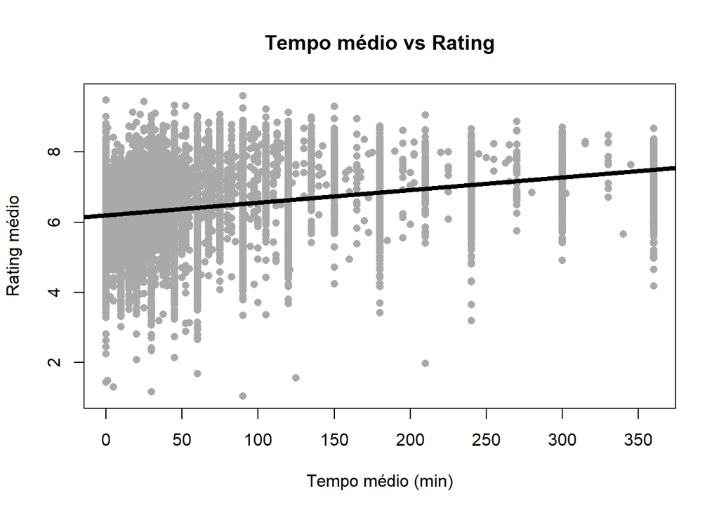

```r
lim <- quantile(boardgames$avg_playtime, 0.98, na.rm = TRUE)

idx <- boardgames$avg_playtime <= lim

plot(boardgames$avg_playtime[idx],
     boardgames$average_rating[idx],
     pch = 16, col = "darkgray",
     xlab = "Tempo médio (min)",
     ylab = "Rating médio",
     main = "Tempo médio vs Rating")

abline(lm(average_rating ~ avg_playtime,
          data = boardgames[idx, ]),
       col = "black", lwd = 4)
```

```r
cor.test(boardgames$avg_playtime,
         boardgames$average_rating,
         method = "spearman",
         use = "complete.obs")
```

```
##
##  Spearman's rank correlation rho
##
## data:  boardgames$avg_playtime and boardgames$average_rating
## S = 1.1407e+12, p-value < 2.2e-16
## alternative hypothesis: true rho is not equal to 0
## sample estimates:
##       rho
## 0.3223564
```

O gráfico sugere que jogos com maior duração tendem, em média, a apresentar classificações ligeiramente superiores.No entanto, a relação observada é fraca, o que indica que o tempo de jogo, isoladamente, tem um impacto limitado na avaliação global.

O mesmo é confirmado pela análise estatística que indica uma correlação positiva fraca a moderada entre o tempo médio de jogo e o rating, sendo estatisticamente significativa (valor-p inferior a 0.001).

Jogos curtos podem ser muito bem avaliados ou mal avaliados, refletindo preferências diversas dos jogadores, enquanto jogos mais longos parecem atrair um público mais específico.

## 4.4 Nº de jogadores vs Rating

Nesta análise pretende-se analisar se o número de jogadores recomendado influencia a classificação média dos jogos. Em particular, procura-se responder à questão (**BI**): existe uma faixa de número de jogadores associada a ratings mais elevados?

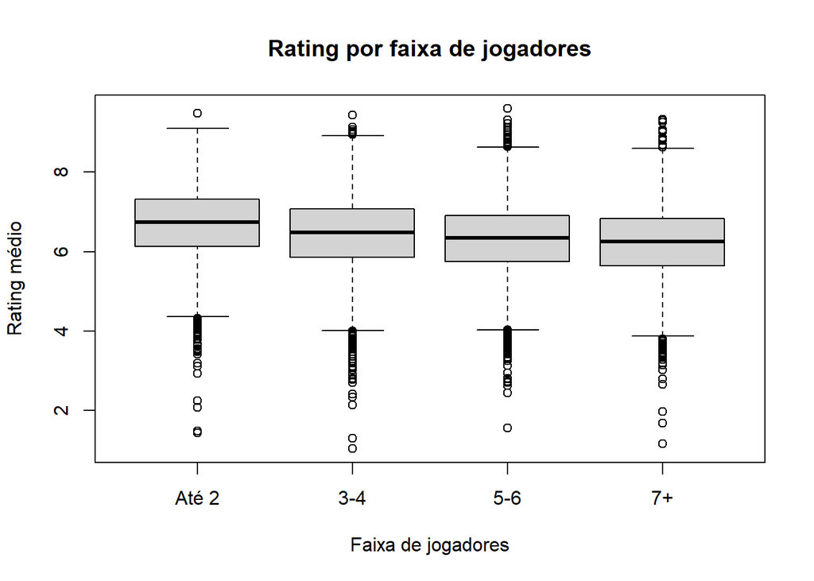

```r
group_size <- ifelse(boardgames$max_players <= 2, "Até 2",
                ifelse(boardgames$max_players <= 4, "3-4",
                ifelse(boardgames$max_players <= 6, "5-6", "7+")))

group_size <- factor(group_size,
                     levels = c("Até 2", "3-4", "5-6", "7+"))

boxplot(boardgames$average_rating ~ group_size,
        main = "Rating por faixa de jogadores",
        xlab = "Faixa de jogadores",
        ylab = "Rating médio",
        col = "lightgray")
```

```r
kruskal.test(boardgames$average_rating ~ group_size)
```

```
##
##  Kruskal-Wallis rank sum test
##
## data:  boardgames$average_rating by group_size
## Kruskal-Wallis chi-squared = 683.12, df = 3, p-value < 2.2e-16
```

Para complementar esta análise visual, foi aplicado o teste estatístico de Kruskal–Wallis, adequado à comparação de mais de dois grupos sem assumir normalidade das distribuições. O teste indica a existência de diferenças estatisticamente significativas entre pelo menos duas das faixas de jogadores (valor-p inferior a 0.001).

No entanto, apesar da significância estatística, as diferenças observadas entre as distribuições são pequenas do ponto de vista prático.

De forma geral, os resultados indicam que jogos bem ou mal avaliados existem em todas as faixas de jogadores, o que reforça a ideia de que o rating depende de múltiplos fatores e não apenas do tamanho do grupo.

## 4.5 Ano de publicação vs Rating

O objectivo desta análise é estudar a relação entre o ano de publicação dos jogos e o respetivo rating médio. O objetivo é responder à questão (**BI**): jogos mais recentes tendem a ser melhor avaliados do que jogos mais antigos?

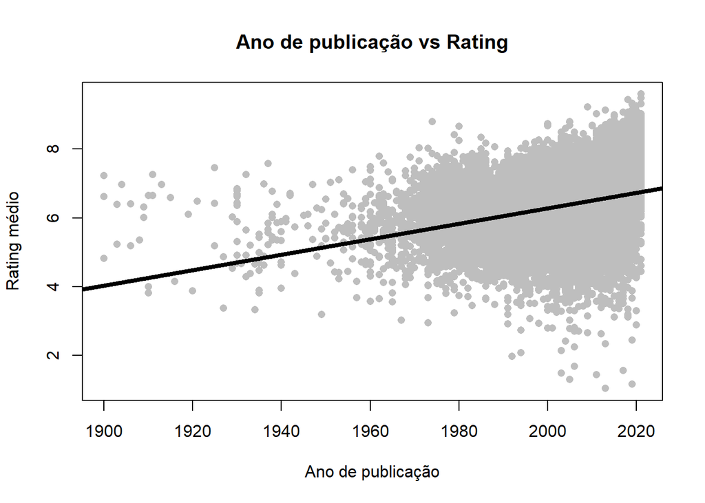

```r
plot(boardgames$year_published, boardgames$average_rating,
     pch = 16,
     col = "gray",
     xlab = "Ano de publicação",
     ylab = "Rating médio",
     main = "Ano de publicação vs Rating")

abline(lm(average_rating ~ year_published, data = boardgames),
       col = "black", lwd = 4)
```

```r
cor.test(boardgames$year_published,
         boardgames$average_rating,
         method = "spearman",
         use = "complete.obs")
```

```
##
##  Spearman's rank correlation rho
##
## data:  boardgames$year_published and boardgames$average_rating
## S = 9.635e+11, p-value < 2.2e-16
## alternative hypothesis: true rho is not equal to 0
## sample estimates:
##      rho
## 0.427632
```

A análise gráfica e estatística revela uma correlação positiva moderada e estatisticamente significativa (p-value < 0.001), indicando que jogos publicados mais recentemente apresentam, em média, classificações ligeiramente superiores.

Este padrão poderá refletir melhorias no design, maior diversidade temática e uma maior maturidade da indústria. Ainda assim, a dispersão ao longo de todo o período evidencia que jogos de elevada e baixa qualidade existem em todas as épocas.

## 4.6 Jogos modernos vs clássicos

Nesta análise pretende-se complementar a análise temporal contínua, e procede-se à comparação direta entre jogos clássicos (publicados antes de 2000) e modernos (publicados a partir de 2000), avaliando diferenças no rating médio entre estes dois grupos.

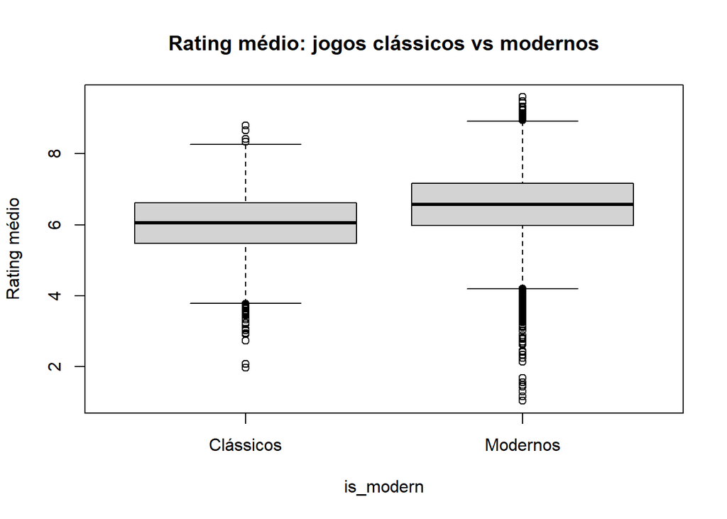

```r
boxplot(average_rating ~ is_modern,
        data = boardgames,
        names = c("Clássicos", "Modernos"),
        main = "Rating médio: jogos clássicos vs modernos",
        ylab = "Rating médio",
        col = "lightgray")
```

```r
wilcox.test(average_rating ~ is_modern, data = boardgames)
```

```
##
##  Wilcoxon rank sum test with continuity correction
##
## data:  average_rating by is_modern
## W = 26153856, p-value < 2.2e-16
## alternative hypothesis: true location shift is not equal to 0
```

Para validar esta observação, foi aplicado o teste não paramétrico de Wilcoxon, adequado à comparação de duas distribuições independentes sem assumir normalidade. O teste indica uma diferença estatisticamente significativa entre os dois grupos (p-value < 0.001).

O resultado verificado reforça a tendência observada anteriormente, que sugere que a evolução da indústria, nomeadamente melhorias no design, diversidade temática e alinhamento com as preferências atuais dos jogadores, poderá ter contribuído para avaliações médias mais elevadas nos jogos modernos.

# 5 Análise Multivariada

A análise multivariada permite avaliar simultaneamente várias características dos jogos, de modo a identificar padrões globais e relações conjuntas entre as variáveis numéricas do dataset.

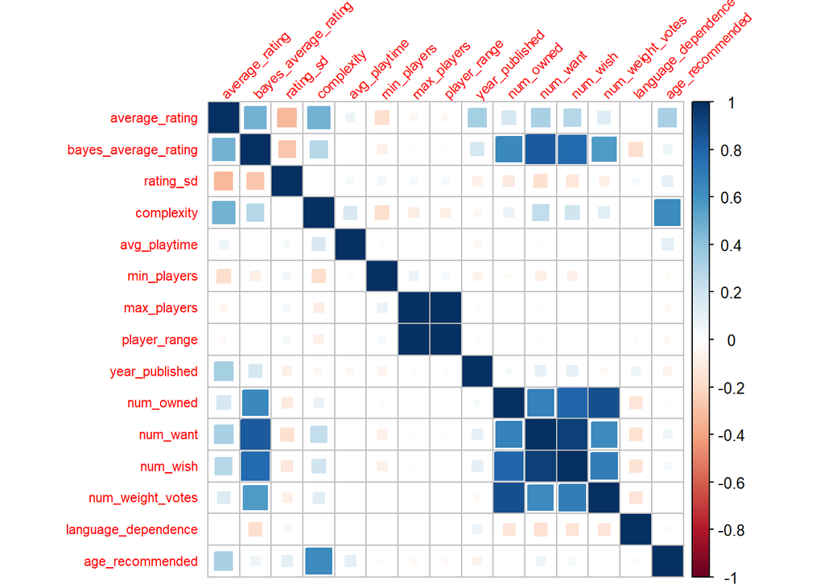

```r
num_vars <- boardgames[, c(
  "average_rating", "bayes_average_rating", "rating_sd",
  "complexity", "avg_playtime",
  "min_players", "max_players", "player_range",
  "year_published",
  "num_owned", "num_want", "num_wish", "num_weight_votes",
  "language_dependence", "age_recommended"
)]
m_corr <- cor(num_vars, use = "pairwise.complete.obs")
corrplot(m_corr,
         method = "square",
         tl.cex = 0.7,
         tl.srt = 45)
```

As variáveis relacionadas com popularidade e envolvimento da comunidade (*num_owned*, *num_want*, *num_wish* e *num_weight_votes*) estão fortemente correlacionadas entre si, sugerindo que jogos mais populares tendem a concentrar maior interação dos utilizadores.

No geral, os resultados indicam que a avaliação dos jogos depende de múltiplos fatores e não de uma única característica isolada.

## 5.1 Redução dimensional (PCA)

Após identificar relações relevantes entre várias variáveis numéricas, torna-se pertinente aplicar uma técnica de redução de dimensão, como a Análise de Componentes Principais (PCA), com o objetivo de sintetizar a informação e explorar padrões globais no conjunto de jogos.

```r
pca_vars <- boardgames[, c(
  "complexity", "avg_playtime",
  "min_players", "max_players", "player_range",
  "year_published",
  "num_owned", "num_want", "num_wish", "num_weight_votes"
)]

pca_vars <- pca_vars[complete.cases(pca_vars), ]


pca <- prcomp(scale(pca_vars), center = TRUE, scale. = TRUE)
summary(pca)
```

```
## Importance of components:
##                           PC1    PC2    PC3    PC4     PC5     PC6     PC7
## Standard deviation     1.8367 1.4224 1.0917 1.0527 0.97133 0.85828 0.67737
## Proportion of Variance 0.3373 0.2023 0.1192 0.1108 0.09435 0.07366 0.04588
## Cumulative Proportion  0.3373 0.5397 0.6589 0.7697 0.86403 0.93769 0.98358
##                            PC8     PC9      PC10
## Standard deviation     0.35980 0.18649 1.776e-14
## Proportion of Variance 0.01295 0.00348 0.000e+00
## Cumulative Proportion  0.99652 1.00000 1.000e+00
```

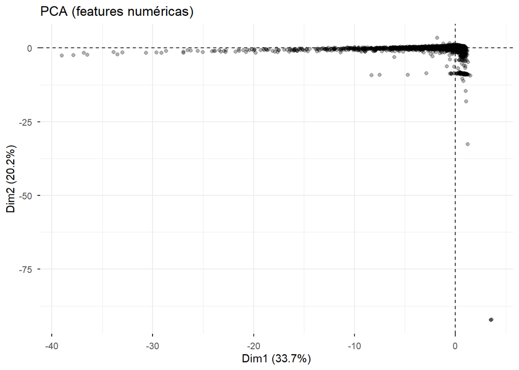

```r
fviz_pca_ind(pca, geom = "point", alpha = 0.3) +
  ggtitle("PCA (features numéricas)")
```

Os resultados indicam que os dois primeiros componentes explicam cerca de 54% da variância total, enquanto quatro componentes permitem representar aproximadamente 77% da informação original, o que evidencia alguma redundância entre as variáveis analisadas.

A projeção dos jogos no espaço definido pelos dois primeiros componentes não revela grupos claramente separados, mas sim uma distribuição contínua, com alguns outliers. Assim, a PCA confirma a relação entre as variáveis e é útil como ferramenta exploratória para síntese dos dados.

## 5.2 Clustering de jogos

De forma complementar à PCA, foi aplicada uma técnica de clustering com o objetivo de identificar perfis distintos de jogos, com base em características semelhantes.

```r
cluster_vars <- boardgames[, c(
  "complexity",
  "avg_playtime",
  "min_players",
  "max_players",
  "year_published",
  "num_owned",
  "num_weight_votes"
)]
cluster_vars <- na.omit(cluster_vars)
cluster_scaled <- scale(cluster_vars)
wss <- numeric(10)

for (k in 1:10) {
  set.seed(123)
  km <- kmeans(cluster_scaled, centers = k, nstart = 25)
  wss[k] <- km$tot.withinss
}
```

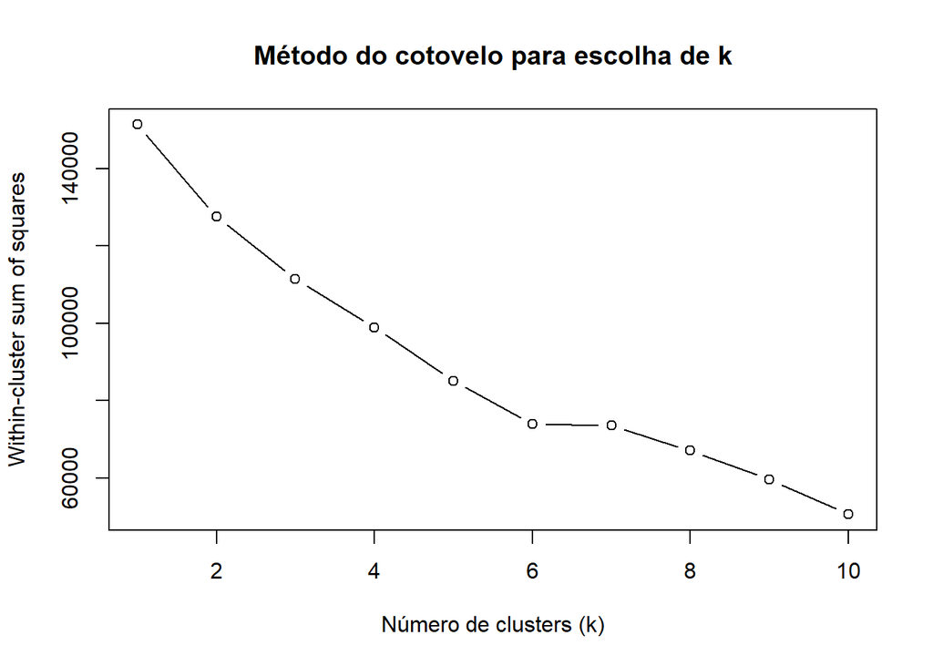

```r
plot(1:10, wss, type = "b",
     xlab = "Número de clusters (k)",
     ylab = "Within-cluster sum of squares",
     main = "Método do cotovelo para escolha de k")
```

```r
set.seed(123)
km_bg <- kmeans(cluster_scaled, centers = 3, nstart = 25)
cluster_vars <- as.data.frame(cluster_vars)
cluster_vars$cluster <- factor(km_bg$cluster)
table(cluster_vars$cluster)
```

```
##
##     1     2     3
## 12441   189  8986
```

```r
cluster_summary <- aggregate(cluster_vars[, -ncol(cluster_vars)],
                            by = list(Cluster = cluster_vars$cluster),
                            mean)

cluster_summary
```

```
##   Cluster complexity avg_playtime min_players max_players year_published
## 1       1   1.429054     35.05864    2.221767    6.885942       2007.249
## 2       2   2.490307     71.33333    1.978836    5.582011       2006.005
## 3       3   2.746727    137.00217    1.708324    4.041509       2006.708
##    num_owned num_weight_votes
## 1   778.3521          22.7284
## 2 44006.7354        1649.2698
## 3  1544.3334          52.6223
```

A aplicação do algoritmo *k-means* permitiu identificar três perfis distintos de jogos com base em várias características numéricas. O primeiro cluster agrupa jogos simples, de curta duração e baixa complexidade, geralmente direcionados a um público mais amplo e casual. O segundo cluster corresponde a jogos de complexidade intermédia e duração moderada, e destaca-se pela elevada popularidade junto da comunidade. Por fim, o terceiro cluster reúne jogos mais longos e complexos, tipicamente concebidos para grupos mais pequenos e um público mais experiente.

Esta segmentação evidencia a diversidade de perfis existentes no conjunto de dados e complementa as análises exploratórias anteriores, logo jogos com características bastante distintas coexistem no mercado.

# 6 Business Analytics Preditiva

Após a fase exploratória, a atenção centra-se na vertente preditiva da *Business Analytics*, recorrendo a modelos supervisionados com o objetivo de estimar o rating médio dos jogos e identificar jogos de topo a partir das suas características.

## 6.1 Previsão do rating médio

```r
reg_vars <- boardgames[, c(
  "average_rating", "complexity", "avg_playtime",
  "min_players", "max_players", "player_range",
  "year_published",
  "num_owned", "num_want", "num_wish",
  "num_weight_votes", "is_modern"
)]

reg_vars <- reg_vars[complete.cases(reg_vars), ]

set.seed(123)
n <- nrow(reg_vars)
idx <- sample(1:n, size = 0.8*n)

train <- reg_vars[idx, ]
test  <- reg_vars[-idx, ]


rf_reg <- randomForest(average_rating ~ ., data = train, ntree = 300)
pred <- predict(rf_reg, newdata = test)


mae <- mean(abs(test$average_rating - pred))
r2 <- 1 - sum((test$average_rating - pred)^2) /
           sum((test$average_rating - mean(test$average_rating))^2)
print("MAE:")
```

```
## [1] "MAE:"
```

```r
mae
```

```
## [1] 0.4162113
```

```r
print("R^2:")
```

```
## [1] "R^2:"
```

```r
r2
```

```
## [1] 0.5977438
```

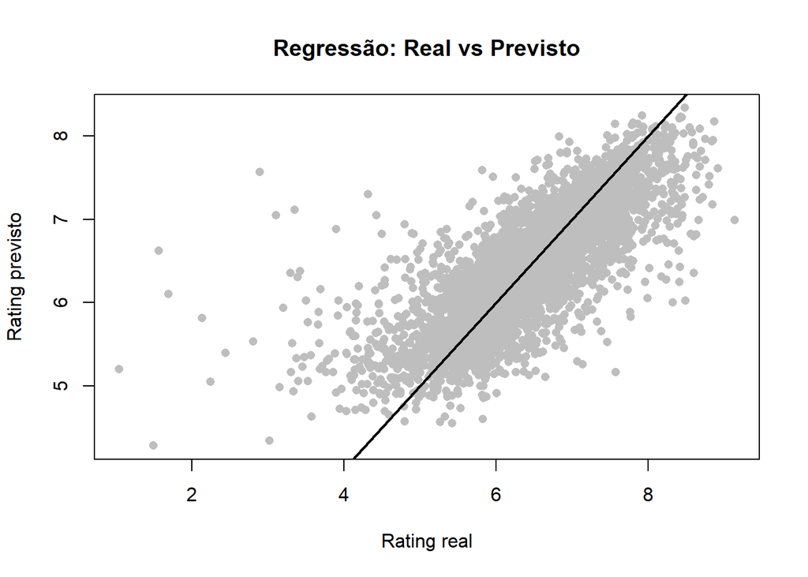

```r
plot(test$average_rating, pred,
     pch = 16, col = "gray",
     xlab = "Rating real",
     ylab = "Rating previsto",
     main = "Regressão: Real vs Previsto")
abline(0,1,col="black",lwd=2)
```

O modelo de regressão baseado em *Random Forest* apresenta um erro absoluto médio (MAE) de aproximadamente 0.42, o que indica que, em média, as previsões diferem do valor real do rating em menos de meio ponto. O coeficiente de determinação (R² = 0.60) mostra que cerca de 60% da variabilidade observada nos ratings é explicada pelas variáveis consideradas.

A análise gráfica entre valores reais e previstos revela que o modelo capta adequadamente a tendência global dos dados, com a maioria dos pontos próxima da linha de referência. Ainda assim, verifica-se uma dispersão mais acentuada para jogos com ratings muito baixos ou muito elevados, o que sugere maior dificuldade na previsão de valores extremos.

Apesar do desempenho razoável do modelo de *Random Forest*, uma parte relevante da variabilidade permanece por explicar. Nesse contexto, a avaliação de um modelo alternativo tornou-se pertinente, de forma a verificar se padrões não lineares adicionais poderiam ser melhor capturados.

```r
reg_vars <- boardgames[, c(
  "average_rating", "complexity", "avg_playtime",
  "min_players", "max_players", "player_range",
  "year_published", "num_owned", "num_want", "num_wish",
  "num_weight_votes", "is_modern"
)]

reg_vars <- reg_vars[complete.cases(reg_vars), ]

set.seed(123)
idx <- sample(seq_len(nrow(reg_vars)), size = 0.8*nrow(reg_vars))

train_xgb <- reg_vars[idx, ]
test_xgb  <- reg_vars[-idx, ]

y_train <- train_xgb$average_rating
y_test  <- test_xgb$average_rating

X_train <- model.matrix(~ . -1, data = train_xgb[, setdiff(names(train_xgb), "average_rating")])
X_test  <- model.matrix(~ . -1, data = test_xgb[,  setdiff(names(test_xgb),  "average_rating")])

dtrain <- xgb.DMatrix(data = X_train, label = y_train)
dtest  <- xgb.DMatrix(data = X_test,  label = y_test)

params <- list(
  objective = "reg:squarederror",
  eta = 0.05,
  max_depth = 6,
  subsample = 0.8,
  colsample_bytree = 0.8
)

xgb_model <- xgb.train(params = params, data = dtrain, nrounds = 300, verbose = 0)
pred_xgb <- predict(xgb_model, dtest)

mae_xgb <- mean(abs(y_test - pred_xgb))
r2_xgb  <- 1 - sum((y_test - pred_xgb)^2) / sum((y_test - mean(y_test))^2)

print("MAE:")
```

```
## [1] "MAE:"
```

```r
mae_xgb
```

```
## [1] 0.4119172
```

```r
print("R^2:")
```

```
## [1] "R^2:"
```

```r
r2_xgb
```

```
## [1] 0.6023361
```

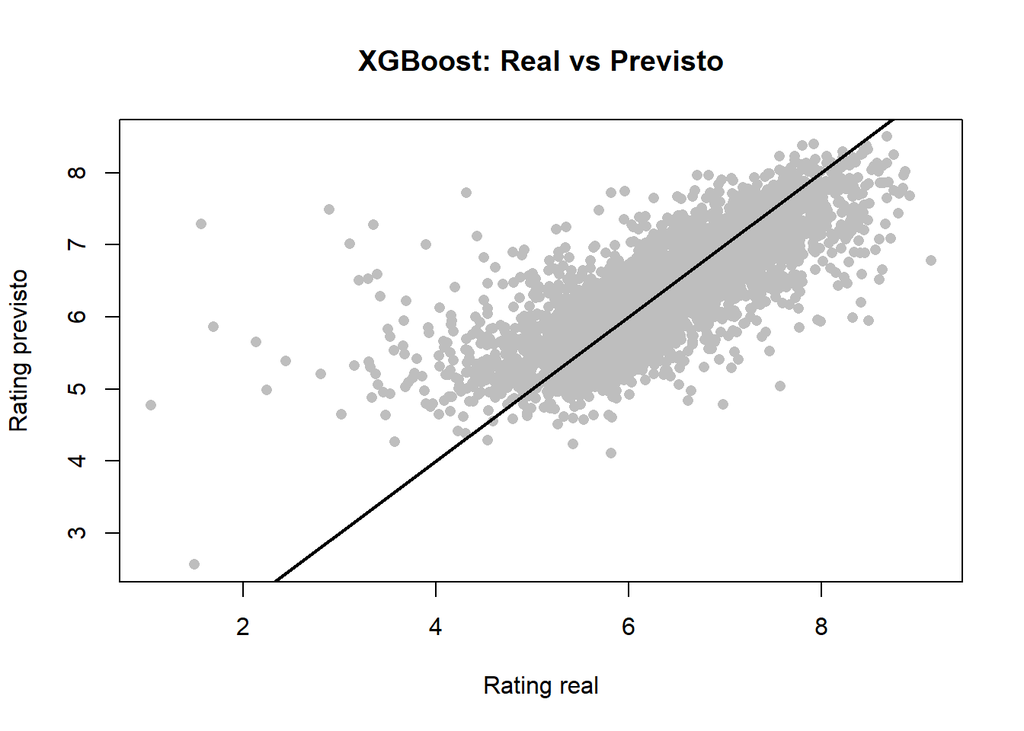

```r
plot(y_test, pred_xgb,
     pch=16, col="gray",
     xlab="Rating real", ylab="Rating previsto",
     main="XGBoost: Real vs Previsto")
abline(0,1,lwd=2)
```

A introdução de um modelo mais sofisticado (*XGBoost*) não resultou numa melhoria substancial face ao Random Forest. Ambos os modelos apresentam valores muito semelhantes de MAE e R², uma vez que a limitação principal não está no algoritmo, mas sim na informação disponível nas variáveis explicativas.

## 6.2 Previsão da classificação

```r
cls_vars <- boardgames[, c(
  "is_top_game", "complexity", "avg_playtime",
  "min_players", "max_players", "player_range",
  "year_published",
  "num_owned", "num_want", "num_wish",
  "num_weight_votes", "is_modern"
)]

cls_vars <- cls_vars[complete.cases(cls_vars), ]

cls_vars$is_top_game <- factor(cls_vars$is_top_game, levels = c(0,1))


set.seed(123)
n <- nrow(cls_vars)
idx <- sample(1:n, size = 0.8*n)

train <- cls_vars[idx, ]
test  <- cls_vars[-idx, ]

rf_cls <- randomForest(is_top_game ~ ., data = train, ntree = 400)

prob <- predict(rf_cls, newdata = test, type = "prob")[, "1"]
pred <- ifelse(prob >= 0.5, 1, 0)

confusionMatrix(factor(pred), test$is_top_game)
```

```
## Confusion Matrix and Statistics
##
##           Reference
## Prediction    0    1
##          0 4148  123
##          1   22   31
##
##                Accuracy : 0.9665
##                  95% CI : (0.9607, 0.9716)
##     No Information Rate : 0.9644
##     P-Value [Acc > NIR] : 0.2448
##
##                   Kappa : 0.2865
##
##  Mcnemar's Test P-Value : <2e-16
##
##             Sensitivity : 0.9947
##             Specificity : 0.2013
##          Pos Pred Value : 0.9712
##          Neg Pred Value : 0.5849
##              Prevalence : 0.9644
##          Detection Rate : 0.9593
##    Detection Prevalence : 0.9877
##       Balanced Accuracy : 0.5980
##
##        'Positive' Class : 0
##
```

```r
roc_obj <- roc(test$is_top_game, prob)
```

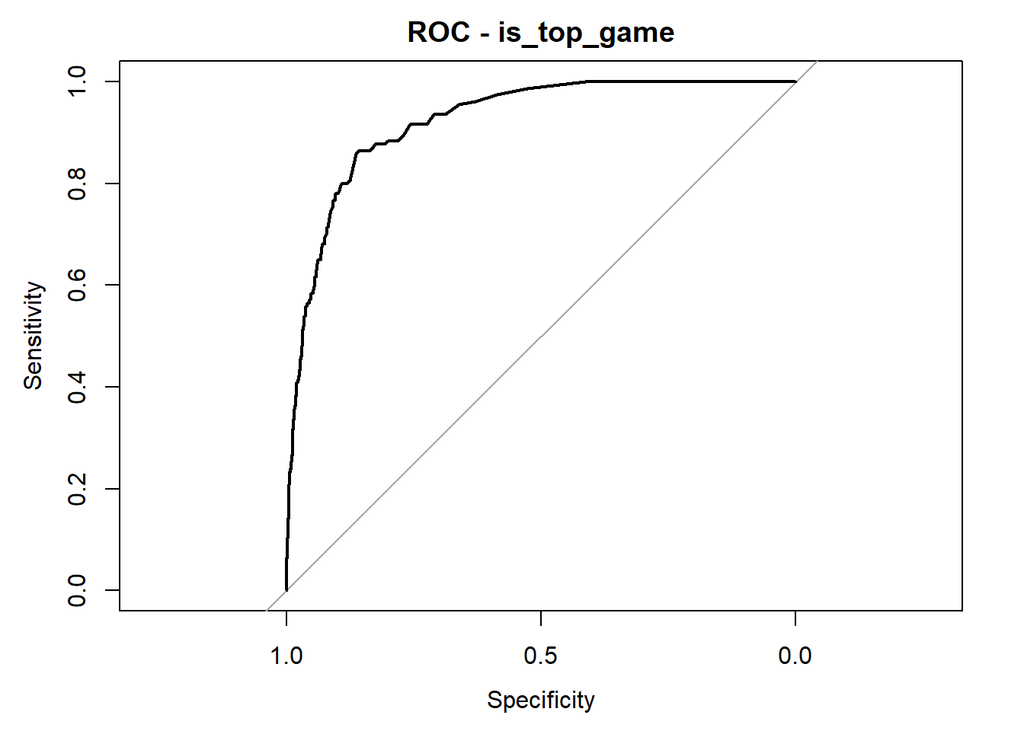

```r
plot(roc_obj, main = "ROC - is_top_game")
```

```r
auc(roc_obj)
```

```
## Area under the curve: 0.9235
```

A avaliação do modelo de classificação baseia-se na matriz de confusão e na curva ROC. A área sob a curva apresenta um valor elevado (AUC = 0.92), o que indica uma excelente capacidade do modelo para distinguir jogos de topo dos restantes quando analisadas as probabilidades previstas.

Apesar deste desempenho global positivo, a análise da matriz de confusão evidencia um forte desbalanceamento entre as classes. A *accuracy* elevada deve-se, em grande parte, à predominância de jogos não classificados como topo no conjunto de dados. A sensibilidade associada à classe “top” revela-se relativamente baixa, o que significa que apenas uma fração dos jogos de topo é corretamente identificada.

Em conjunto, estes resultados mostram que o modelo é eficaz a identificar jogos não-topo e a ordenar jogos por probabilidade de sucesso, mas menos eficaz na deteção direta de jogos de topo.

# 7 Análise Prescriptiva - Recomendação de jogo

Após a análise descritiva e preditiva, procede-se à vertente prescritiva da *Business Analytics*. Enquanto as etapas anteriores permitiram compreender padrões existentes nos dados e estimar resultados futuros, a análise prescritiva tem como objetivo apoiar decisões concretas, respondendo à questão “o que deve ser feito?”.

Neste contexto, foi desenvolvido um sistema simples de recomendação de jogos de tabuleiro, baseado na similaridade de características dos jogos. A lógica do modelo assenta na comparação de atributos como a complexidade, a duração média, o número de jogadores e indicadores de popularidade, permitindo sugerir jogos com perfis semelhantes a partir de um título de referência. Esta abordagem demonstra de que forma a informação disponível pode ser utilizada para apoiar recomendações personalizadas.

```r
rec_vars <- boardgames[, c(
  "id", "name",
  "complexity", "avg_playtime",
  "min_players", "max_players",
  "year_published",
  "num_owned", "num_want", "num_wish",
  "num_weight_votes",
  "average_rating"
)]


rec_vars <- rec_vars[complete.cases(rec_vars), ]


X <- as.matrix(rec_vars[, c(
  "complexity","avg_playtime","min_players","max_players",
  "year_published","num_owned","num_want","num_wish","num_weight_votes"
)])


X <- scale(X)

recommend <- function(game_name, k = 15) {

  i <- which(tolower(rec_vars$name) == tolower(game_name))[1]

  if (is.na(i)) {
    stop("Jogo não encontrado no dataset.")
  }

  v <- X[i, ]

  dot <- as.vector(X %*% v)
  normX <- sqrt(rowSums(X^2))
  normV <- sqrt(sum(v^2))
  sims <- dot / (normX * normV)

  sims[i] <- -1

  top <- order(sims, decreasing = TRUE)[1:k]

  result <- rec_vars[top, c("name", "average_rating")]
  result$similarity <- round(sims[top], 3)


  result <- result[order(result$similarity, decreasing = TRUE), ]
  rownames(result) <- NULL


  cat("JOGO DE REFERÊNCIA:\n")
  cat("   ", rec_vars$name[i],
      "(Rating médio:", round(rec_vars$average_rating[i], 2), ")\n")


  cat("TOP", k, "JOGOS RECOMENDADOS:\n\n")

  for (j in 1:nrow(result)) {
    cat(sprintf(
      "%2d. %-40s | Rating: %.2f | Similaridade: %.3f\n",
      j,
      result$name[j],
      result$average_rating[j],
      result$similarity[j]
    ))
  }
}
```

Para exemplificar esta análise, foram selecionados os jogoss *Catan*, *Wingspan* e *Risk*, que correspondem a alguns dos meus jogos de tabuleiro preferidos. Estes jogos apresentam estilos e categorias distintas, desde jogos de estratégia e gestão mais acessíveis, como *Catan* e *Wingspan*, até um jogo clássico de controlo de território e confronto direto, como *Risk*.

A escolha destes jogos permite avaliar a capacidade do sistema de recomendação em identificar alternativas coerentes em termos de experiência de jogo, ajustando as sugestões ao perfil de cada jogo de referência, mesmo quando pertencem a categorias diferentes.

```r
recommend("Catan", 10)
```

```
## JOGO DE REFERÊNCIA:
##     Catan (Rating médio: 7.14 )
## TOP 10 JOGOS RECOMENDADOS:
##
##  1. Carcassonne                              | Rating: 7.42 | Similaridade: 0.998
##  2. Blokus                                   | Rating: 6.87 | Similaridade: 0.996
##  3. Bohnanza                                 | Rating: 7.04 | Similaridade: 0.995
##  4. Citadels                                 | Rating: 7.08 | Similaridade: 0.994
##  5. Guillotine                               | Rating: 6.53 | Similaridade: 0.989
##  6. Zombies!!!                               | Rating: 5.80 | Similaridade: 0.989
##  7. The Lord of the Rings                    | Rating: 6.75 | Similaridade: 0.988
##  8. Ticket to Ride                           | Rating: 7.41 | Similaridade: 0.988
##  9. Catan Card Game                          | Rating: 6.71 | Similaridade: 0.983
## 10. Fluxx                                    | Rating: 5.67 | Similaridade: 0.982
```

```r
recommend("Risk", 10)
```

```
## JOGO DE REFERÊNCIA:
##     Risk (Rating médio: 5.59 )
## TOP 10 JOGOS RECOMENDADOS:
##
##  1. Killer Bunnies and the Quest for the Magic Carrot | Rating: 5.50 | Similaridade: 0.988
##  2. Catan Card Game                          | Rating: 6.71 | Similaridade: 0.987
##  3. Scrabble                                 | Rating: 6.28 | Similaridade: 0.984
##  4. Monopoly                                 | Rating: 4.37 | Similaridade: 0.983
##  5. Fluxx                                    | Rating: 5.67 | Similaridade: 0.979
##  6. Zombies!!!                               | Rating: 5.80 | Similaridade: 0.977
##  7. Caesar & Cleopatra                       | Rating: 6.40 | Similaridade: 0.973
##  8. UNO                                      | Rating: 5.41 | Similaridade: 0.973
##  9. Labyrinth                                | Rating: 6.41 | Similaridade: 0.970
## 10. Magic: The Gathering                     | Rating: 7.54 | Similaridade: 0.967
```

```r
recommend("Wingspan", 10)
```

```
## JOGO DE REFERÊNCIA:
##     Wingspan (Rating médio: 8.1 )
## TOP 10 JOGOS RECOMENDADOS:
##
##  1. Terraforming Mars                        | Rating: 8.42 | Similaridade: 0.997
##  2. Tokaido                                  | Rating: 6.97 | Similaridade: 0.995
##  3. Scythe                                   | Rating: 8.22 | Similaridade: 0.994
##  4. Century: Spice Road                      | Rating: 7.35 | Similaridade: 0.993
##  5. Descent: Journeys in the Dark (Second Edition) | Rating: 7.67 | Similaridade: 0.991
##  6. Evolution                                | Rating: 7.11 | Similaridade: 0.991
##  7. Robinson Crusoe: Adventures on the Cursed Island | Rating: 7.82 | Similaridade: 0.991
##  8. Star Wars: Imperial Assault              | Rating: 8.00 | Similaridade: 0.991
##  9. Dead of Winter: A Crossroads Game        | Rating: 7.55 | Similaridade: 0.990
## 10. Legends of Andor                         | Rating: 7.19 | Similaridade: 0.989
```

# 8 Conclusão

De forma geral, este trabalho mostrou que o dataset da BoardGameGeek permite extrair informação relevante sobre o mercado de jogos de tabuleiro, tanto numa perspetiva exploratória como analítica.

A análise de *Business Intelligence* evidenciou padrões claros, como a predominância de jogos de complexidade baixa a média, o aumento do número de lançamentos nas últimas décadas e associações moderadas entre o *average_rating*, a *complexity* e o *year_published*.

Na vertente de *Business Analytics*, os modelos preditivos demonstraram desempenho razoável na estimação do *average_rating*, conseguindo captar tendências globais nos dados, embora uma parte significativa da variabilidade permaneça por explicar. Este resultado é expectável, uma vez que as avaliações refletem preferências subjetivas dos utilizadores e fatores não diretamente observáveis no dataset, como o contexto de jogo ou motivações individuais.

Na tarefa de classificação (*is_top_game*), o modelo revelou uma boa capacidade discriminativa quando analisadas as probabilidades previstas, evidenciada por um valor elevado da AUC. Ainda assim, a interpretação da *accuracy* requer cautela devido ao desbalanceamento entre classes, que dificulta a identificação direta da classe minoritária.

Relativamente à análise prescritiva, os resultados indicaram que a construção de um sistema simples de recomendação baseado em conteúdo é viável, mesmo quando se utilizam apenas características numéricas dos jogos. As recomendações obtidas mostraram-se coerentes para diferentes perfis, sugerindo utilidade prática deste tipo de abordagem. Contudo, a aplicação real destes resultados depende da qualidade e representatividade dos dados disponíveis, sendo relevante considerar a presença de valores em falta, possíveis enviesamentos associados à plataforma BoardGameGeek e eventuais atrasos no registo de jogos mais recentes.

Em síntese, o trabalho evidencia que a combinação de *Business Intelligence* e *Business Analytics* aplicada a dados reais permite compreender padrões relevantes e apoiar processos de decisão. A utilidade destas abordagens depende, no entanto, de uma interpretação crítica dos resultados e de uma clara consciência das limitações inerentes ao dataset e às métricas utilizadas.